# Generalized Gaussian Process using NNGP

Victor Hugo Nagahama

2022-12-01

Generalized Gaussian Process (GGP) are latent Gaussian Process (GP) which the response variable belong to a distribution of exponential family. Nearest Neighbour Gaussian Process (NNGP) is an alternative for GPs that becomes infeasible for large number of locations.

# Inference of latent Gaussian Process model

There are two interest quantities that we want to estimate in a latent Gaussian Process model, the latent field $\pi(\boldsymbol{x} \mid \boldsymbol{y})$ and the posterior distribution of parameters $\pi(\boldsymbol{\theta} \mid \boldsymbol{y})$.

Let the vector of parameters $\boldsymbol{\theta}$, then the expression of its posterior distribution can be obtained using conditional probability properties

$$\begin{equation*}
\pi(\boldsymbol{\theta} \mid \boldsymbol{y}) \propto
\frac{\pi(\boldsymbol{y} \mid \boldsymbol{x}, \boldsymbol{\theta})
\pi(\boldsymbol{x} \mid \boldsymbol{\theta})}{\pi(\boldsymbol{x} \mid
\boldsymbol{y}, \boldsymbol{\theta})}.
\end{equation*}$$

The full conditional density in the denominator has no analytical form. A convenient solution is to assume a known $\boldsymbol{\theta}$, rewrite the expression as $\pi(\boldsymbol{x} \mid \boldsymbol{y}) = \pi(\boldsymbol{x}, \boldsymbol{y}) / \pi(\boldsymbol{y})$ and obtain an approximation applying a second-order Taylor expansion (Laplace approximation) on the log joint density at the mode of posterior $\pi(\boldsymbol{x} \mid \boldsymbol{y})$

$$\begin{align}
\pi(\boldsymbol{x} \mid \boldsymbol{y}) & =
\frac{\pi(\boldsymbol{y} \mid \boldsymbol{x})
\pi(\boldsymbol{x})}{\pi(\boldsymbol{y})} \nonumber \\
& \propto \pi(\boldsymbol{x}) \pi(\boldsymbol{y} \mid
\boldsymbol{x}) \tag{posterior of latent field}.
\end{align}$$

Iterative applications of the Taylor expansion under regular conditions converges a good approximation of the desired conditional density $\tilde{\pi}(\boldsymbol{x} | \boldsymbol{y})$ which in fact it is a multivariate normal distribution will be demonstrated in the section bellow. After obtaining the approximation, the posterior of parameters resumes to

$$\begin{equation*}
\tilde{\pi}(\boldsymbol{\theta} \mid \boldsymbol{y}) \propto
\frac{\pi(\boldsymbol{y} \mid \boldsymbol{x}, \boldsymbol{\theta}) \pi
(\boldsymbol{x} \mid
\boldsymbol{\theta})}{|\boldsymbol{Q}_{\boldsymbol{x} \mid
\boldsymbol{y}}|^{1/2}},
\end{equation*}$$

where $\boldsymbol{Q}_{\boldsymbol{x} \mid \boldsymbol{y}}$ is the precision matrix of the approximation of full conditional of latent field $\tilde{\pi}(\boldsymbol{x} | \boldsymbol{y})$.

So basically the parameters and latent field are jointly estimated. In fact, we assume an initial values for those, compute the Laplace approximation updating the estimation of latent field and evaluate the posterior of parameters.

# Nearest Neighbour Gaussian Process (NNGP)

We can formalise the definition on NNGP as following. Consider a set of locations $\boldsymbol{S} = \{ \boldsymbol{s}_1, \boldsymbol{s}_2, \dots, \boldsymbol{s}_n \}$ where the data was sampled, for each location $\boldsymbol{s}_i$ we have a subset $\boldsymbol{c}(i)$ defined as the $m$ nearest neighbors of $\boldsymbol{s}_i$ then the approximation of $\pi(\boldsymbol{x})$ is given by

$$\begin{equation}
\tilde{\pi}(\boldsymbol{x}) = \prod_{i=1}^n \pi \left( x_i \mid
\boldsymbol{x}_{\boldsymbol{c}(i)} \right),
\label{joint density of nngp}
\end{equation}$$

where each conditional density follows a normal distribution with parameters

$$\begin{equation}
x_i \mid \boldsymbol{x}_{\boldsymbol{c}(i)} \sim \mathcal{N} \left(
\boldsymbol{a}_i \boldsymbol{x}_{\boldsymbol{c}(i)}, d_i \right) \quad
\begin{cases}
\boldsymbol{a}_i = C(\boldsymbol{s}_i, \boldsymbol{c}(i))
\left(C(\boldsymbol{c}(i), \boldsymbol{c}(i) \right)^{-1} \\
d_i = C(\boldsymbol{s}_i, \boldsymbol{s}_i) - \boldsymbol{a}_i^T
C(\boldsymbol{c}(i), \boldsymbol{s}_i)
\end{cases}.
\label{conditional densities of nngp}
\end{equation}$$

The goal here is to find the parameters of the multivariate normal distribution in $\eqref{joint density of nngp}$. In order to obtain that, we write the conditional densities as a linear combination of normal densities $\gamma_i \sim \mathcal{N}(0, d_i)$

$$\begin{align*}
x_1 & = \gamma_1 \\
x_2 & = a_{21} x_1 + \gamma_2 \\
x_3 & = a_{31} x_1 + a_{32} x_2 + \gamma_3 \\
\vdots & \qquad \vdots \\
x_n & = a_{n1} x_1 + a_{n2} x_2 + \dots + \gamma_n.
\end{align*}$$

Stacking the vectors we have

$$\begin{equation*}
\boldsymbol{x} = \boldsymbol{A} \boldsymbol{x} +
\boldsymbol{\gamma},
\end{equation*}$$

where $\boldsymbol{A} = (a_{ij})$ is a lower triangular matrix and $\boldsymbol{\gamma} \sim \mathcal{N}(\boldsymbol{0}, \boldsymbol{D})$ with $\boldsymbol{D} = diag(d_1, \dots, d_n)$. Finally we have the specification of $\eqref{joint density of nngp}$ which has a sparse precision matrix and Cholesky decomposition $\boldsymbol{L}^T \boldsymbol{L}$

$$\begin{align*}
& \boldsymbol{x} = \boldsymbol{A} \boldsymbol{x} +
\boldsymbol{\gamma} \\
& \Leftrightarrow \boldsymbol{x} - \boldsymbol{A} \boldsymbol{x} =
\boldsymbol{\gamma} \\
& \Leftrightarrow (\boldsymbol{I} - \boldsymbol{A}) \boldsymbol{x}
= \boldsymbol{\gamma} \\
& \Leftrightarrow \boldsymbol{x} = (\boldsymbol{I} -
\boldsymbol{A})^{-1} \boldsymbol{\gamma} \\
& \therefore \boldsymbol{x} \sim \mathcal{N} \left(
\boldsymbol{0}, \underbrace{(\boldsymbol{I} - \boldsymbol{A})^{-1}
\boldsymbol{D} (\boldsymbol{I} -
\boldsymbol{A})^{-T}}_{\tilde{\boldsymbol{C}}} \right)
\end{align*}$$

$$\begin{align}
\tilde{\boldsymbol{C}}^{-1} & = (\boldsymbol{I} -
\boldsymbol{A})^T \boldsymbol{D}^{-1} (\boldsymbol{I} - \boldsymbol{A})
\nonumber \\
\boldsymbol{L} & = \boldsymbol{D}^{-1/2} (\boldsymbol{I} -
\boldsymbol{A}). \label{cholesky}
\end{align}$$

# Laplace approximation

Let a vector of non-normal response $\boldsymbol{y}$ belonging to exponential family and a latent field $\boldsymbol{x} \sim GP(\boldsymbol{\mu}, \boldsymbol{C}^{-1})$. We want to to approximate the full conditional density $\pi(\boldsymbol{x} \mid \boldsymbol{y}, \boldsymbol{\theta})$ as $\tilde{\pi}(\boldsymbol{x} \mid \boldsymbol{y}, \boldsymbol{\theta})$, in order to do that we apply a second order Taylor expansion on $\log \pi (\boldsymbol{y} \mid \boldsymbol{x}, \boldsymbol{\theta})$.

Consider $g(\boldsymbol{x}) = \log \pi (\boldsymbol{y} \mid \boldsymbol{x}, \boldsymbol{\theta})$ for a given $\boldsymbol{\theta}$ and for ease of notation $\nabla g^{(0)} = \left [ g'(\boldsymbol{x}^{(0)}) \right ]$ and $\boldsymbol{H}^{(0)} = \textrm{diag} \left( g''(\boldsymbol{x}^{(0)}) \right)$

$$\begin{align*}
\pi(\boldsymbol{y} \mid \boldsymbol{x}, \boldsymbol{\theta}) &
\approx \exp \left\{ g(\boldsymbol{x}^{(0)}) + \left(\boldsymbol{x} -
\boldsymbol{x}^{(0)}\right)^T \nabla g^{(0)} + \frac{1}{2}
\left(\boldsymbol{x} - \boldsymbol{x}^{(0)}\right)^T
\boldsymbol{H}^{(0)} \left(\boldsymbol{x} - \boldsymbol{x}^{(0)}\right)
\right\} \\
& = \exp \left\{ \boldsymbol{x}^T \left( \nabla g^{(0)} -
\boldsymbol{H}^{(0)} \boldsymbol{x}^{(0)} \right) - \frac{1}{2}
\boldsymbol{x}^T \boldsymbol{H}^{(0)} \boldsymbol{x} \right\} +
\textrm{const} \\
& \approx \exp \left\{ \boldsymbol{x}^T \left( \nabla g^{(0)} -
\boldsymbol{H}^{(0)} \boldsymbol{x}^{(0)} \right) - \frac{1}{2}
\boldsymbol{x}^T \boldsymbol{H}^{(0)} \boldsymbol{x} \right\}.
\end{align*}$$

Replacing the above equation in $\eqref{posterior of latent field}$ and rearranging the terms we obtain the Gaussian approximation of the posterior distribution of latent field named $\tilde{\pi}(\boldsymbol{x} \mid \boldsymbol{y}, \boldsymbol{\theta})$.

$$\begin{align*}
\tilde{\pi}(\boldsymbol{x} \mid \boldsymbol{y}, \boldsymbol{\theta})
& \propto \pi(\boldsymbol{x} \mid \boldsymbol{\theta})
\pi(\boldsymbol{y} \mid \boldsymbol{x}, \boldsymbol{\theta}) \\
& \approx \exp \left\{ \boldsymbol{x}^T \boldsymbol{Q}
\boldsymbol{\mu} - \frac{1}{2} \boldsymbol{x}^T \boldsymbol{Q}
\boldsymbol{x} \right\} \exp \left\{ \boldsymbol{x}^T \left( \nabla
g^{(0)} - \boldsymbol{H}^{(0)} \boldsymbol{x}^{(0)} \right) -
\frac{1}{2} \boldsymbol{x}^T \boldsymbol{H}^{(0)} \boldsymbol{x}
\right\} \\
& = \exp \left\{ \boldsymbol{x}^T \left( \nabla g^{(0)} -
\boldsymbol{H}^{(0)} \boldsymbol{x}^{(0)} + \boldsymbol{Q}
\boldsymbol{\mu} \right) - \frac{1}{2} \boldsymbol{x}^T \left(
\boldsymbol{Q} + \boldsymbol{H}^{(0)} \right) \boldsymbol{x} \right\},
\end{align*}$$

which is a multivariate normal distribution with parameters

$$\begin{align}
\boldsymbol{\mu}^{(0)}_{\boldsymbol{x} \mid \boldsymbol{y}} & =
\boldsymbol{\mu} + \boldsymbol{Q}^{-1}_{\boldsymbol{x} \mid
\boldsymbol{y}} \left( \nabla g^{(0)} - \boldsymbol{H}^{(0)}
\boldsymbol{x}^{(0)} \right) \label{posterior mean of x} \\
\boldsymbol{Q}^{(0)}_{\boldsymbol{x} \mid \boldsymbol{y}} & =
\boldsymbol{Q} - \boldsymbol{H}^{(0)}. \label{posterior precision matrix
of x}
\end{align}$$

Note that the approximation depends on $\boldsymbol{x}^{(0)}$ and vector of parameters $\boldsymbol{\theta}$, iterated applications of the quadratic approximation under regularity conditions converges to the mode of $\pi (\boldsymbol{x} \mid \boldsymbol{y}, \boldsymbol{\theta})$ and consequently produces a good approximation of its distribution. The method mentioned is actually the application of a Newton-Raphson algorithm on the log posterior of latent field as showed by Zilber and Katzfuss (2021).

# Implementation

Consider a data

$$\begin{align*}
\boldsymbol{x} & \sim \mathcal{N} \left( \boldsymbol{0},
\boldsymbol{C}(\boldsymbol{\psi}) \right) \\
y_i \mid \boldsymbol{x} & \overset{iid}\sim Poisson(\eta_i), \quad
\eta_i = \exp x_i,
\end{align*}$$

where the covariance matrix $C(\boldsymbol{\psi})$ is the Squared Exponential (SE) kernel in terms of signal variance and length-scale parameterization

$$\begin{equation*}
\mathrm{C}(s_i, s_j) = \sigma^2 \exp \left\{ -\frac{(s_i - s_j)^2}{2
l^2} \right\}.
\end{equation*}$$

```r
library(ggplot2)
library(mvtnorm)
```

```r
n <- 15
set.seed(163)
coords <- cbind(runif(n), runif(n))

ord <- order(coords[,1])
coords <- coords[ord,]

sigma <- 1.6
l <- .4

d <- dist(coords) |>
  as.matrix()
C <- sigma^2 * exp(-d / (2 * l^2))
x <- rmvnorm(1, sigma = C, method = "chol", checkSymmetry = F) |>
  c()
eta <- exp(x)
y <- rpois(n, eta)
```

The code above simulate 15 locations in the spatial domain $\mathcal{D} = [0, 1]^2$ following the mentioned data with covariance parameters $\sigma =$ 1.6 and $l =$ 0.4.

## NNGP: Find the neighbours of each location

For simplicity we are using the function `spConjNNGP()` from the package `spNNGP` to get the $m$ nearest neighbours of each location.

```r
get_NN_ind <- function(ind, ind_distM_i, M){
  l <- ifelse(ind < M, ind, M)
  D_i <- rep(0, M);
  D_i[1:l] <- c(ind_distM_i[[ind]])[1:l]
  return(D_i)
}

get_nn <- function(coords, m){
  n <- dim(coords)[1]
  nn_data <- spNNGP::spConjNNGP(
    rep(0, n) ~ 1, coords = coords,
    n.neighbors = m,
    theta.alpha = c("phi" = 5, "alpha" = 0.5),
    sigma.sq.IG = c(2, 1),
    cov.model = "exponential",
    return.neighbor.info = T, fit.rep = F,
    verbose = F)
  ord <- nn_data$neighbor.info$ord
  nn_idx <- sapply(1:(n - 1), get_NN_ind, nn_data$neighbor.info$n.indx[-1], m) |>
    t()

  return(list(ord = ord, nn_idx = nn_idx))
}
```

The code bellow shows the neighbours of the locations 2 to 6, considering a neighbour size equals to 3.

```r
nn <- get_nn(coords, 3)
print(nn$nn_idx[1:5,])
```

```
##      [,1] [,2] [,3]
## [1,]    1    0    0
## [2,]    1    2    0
## [3,]    1    3    2
## [4,]    4    1    3
## [5,]    2    5    4
```

## NNGP: Compute precision matrix

The function `nngp_chol()` compute the $\boldsymbol{A}$ and $\boldsymbol{D}$ matrices and the Cholesky decomposition of the precision matrix using $\eqref{conditional densities of nngp}$ and $\eqref{cholesky}$. The main idea of the algorithm is to initialise $\boldsymbol{A} = (\boldsymbol{a}_1, \dots, \boldsymbol{a}_n)$ as matrix of zeros and the vector $\boldsymbol{d} = diag(\boldsymbol{D})$ with $d_1 = C(\boldsymbol{S}_1, \boldsymbol{S}_1)$ then for each location $i = 2, \dots, n$ we update the matrix and vector according to its neighbours.

```r
# Compute Cholesky decomposition of the precision matrix returning A, D^{-1} and
# L matrices. (Q = (I - A)^T D^{-1} (I - A), where L = D^{-1/2} (I - A))
nngp_chol <- function(coords, m, p) {
  n <- dim(coords)[1]
  sigma <- p[1]
  l <- p[2]

  # Initialize A and dd = diag(D)
  A <- matrix(rep(0, n^2), n)
  dd <- c(sigma^2, rep(0, n - 1))

  # Get the neighbour list
  nn_list <- get_nn(coords, m)

  # Parallelize
  for (i in 1:(n - 1)) {
    nn <- nn_list$nn_idx[i, ]
    nn <- nn[nn != 0]
    d <- dist(coords[c(i + 1, nn),]) |>
      as.matrix()
    C <- sigma^2 * exp(-d / (2 * l^2))
    A[i + 1, nn] <- solve(C[-1, -1], C[-1, 1])
    dd[i + 1] <- C[1, 1] - C[1, -1] %*% A[i + 1, nn]
  }

  Dinv <- diag(1 / dd, nrow = n)
  L <- tcrossprod(diag(sqrt(1 / dd), nrow = n), t(diag(nrow = n) - A))

  l <- list(A = A, Dinv = Dinv, L = L)
  return(l)
}
```

For example, let’s calculate for location of index 8. Assuming known parameters and $m = 3$, first we initialise $\boldsymbol{A}$ and $\boldsymbol{d}$ (named `dd` in the code bellow); and obtain the neighbours for each point.

```r
# Initialize A and dd = diag(D)
A <- matrix(rep(0, n^2), n)
dd <- c(sigma^2, rep(0, n - 1))

# Get the neighbour list
nn_list <- get_nn(coords, 3)

i <- 8

nn <- nn_list$nn_idx[i, ]
nn <- nn[nn != 0]
nn
```

```
## [1] 6 7 2
```

Then we compute the covariance matrix between the location 9 and its neighbours.

```r
d <- dist(coords[c(i + 1, nn),]) |>
  as.matrix()
Cm <- sigma^2 * exp(-d / (2 * l^2))

Cm
```

```
##           1         2        3         4
## 1 2.5600000 1.4970040 1.316674 0.5635524
## 2 1.4970040 2.5600000 1.688977 0.8498077
## 3 1.3166740 1.6889775 2.560000 0.6011870
## 4 0.5635524 0.8498077 0.601187 2.5600000
```

Considering the neighbours of 9 use $\eqref{conditional densities of nngp}$ to compute $\boldsymbol{a}_9$ and $d_9$ and update $\boldsymbol{A}$ and $\boldsymbol{d}$.

```r
A[i + 1, nn] <- solve(Cm[-1, -1], Cm[-1, 1])
dd[i + 1] <- Cm[1, 1] - Cm[1, -1] %*% A[i + 1, nn]
```

```r
A[i + 1,]
```

```
##  [1] 0.00000000 0.02520721 0.00000000 0.00000000 0.00000000 0.42671532 0.22687782 0.00000000
##  [9] 0.00000000 0.00000000 0.00000000 0.00000000 0.00000000 0.00000000 0.00000000
```

```r
dd[i + 1]
```

```
## [1] 1.608276
```

After applying the procedure for all $i = 2, \dots, n$ we obtain the computed matrix $\boldsymbol{A}$ and $\boldsymbol{D}$. In images bellow black represents non zero values.

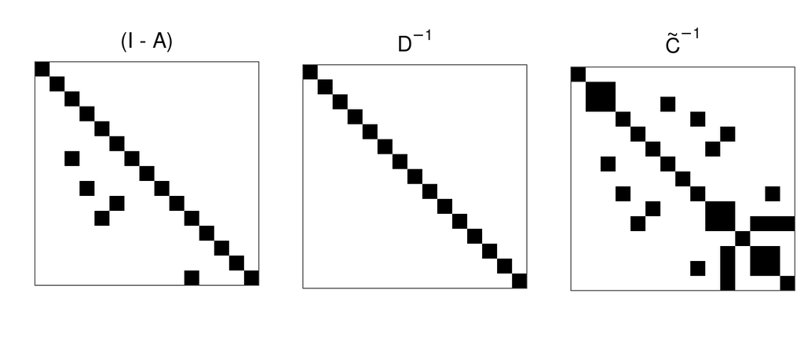

Also we can compare the full GP (original) precision matrix and the NNGP version.

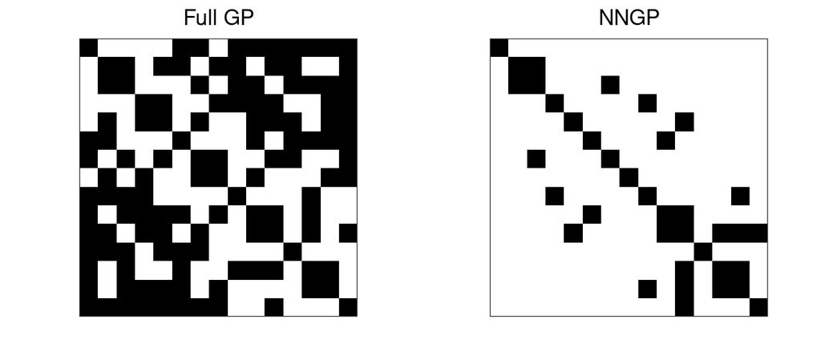

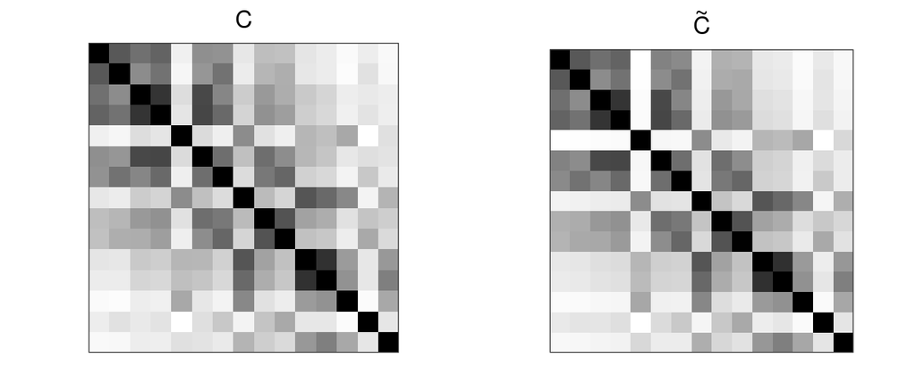

## Laplace approximation: Compute full posterior of latent field

The function `la()` compute the Laplace Approximation of the posterior of latent field.

```r
# Laplace Approximation of pi(y | x)
la <- function(x0, y, Cinv, grad, hess, control = list(it = 100, tol = 1e-4)) {
  for (i in 1:control$it) {
    # Rearanging means
    H <- diag(hess(x0), length(x0))
    G <- grad(x0, y)
    Cx <- chol2inv(chol(Cinv - H)) # improve?
    mu <- as.vector(Cx %*% (G - H %*% x0))

    # N-R algorithm
    # U <- grad(x0, y)
    # D <- diag(-1 / hess(x0), length(x0))
    # Dinv <- diag(-hess(x0), length(x0))
    # Winv <- chol2inv(chol(Cinv + Dinv))
    # t <- x0 + D %*% U
    # mu <- Winv %*% (Dinv %*% t)

    if (max(abs(x0 - mu)) < control$tol) break
    if (i == control$it) stop("Max iteration number reached")
    x0 <- mu
  }

  parms <- list(mu = mu, sigma = Cx)
  return(parms)
}
```

For simplicity let’s show the approximation for a univariate setting $y \mid x \sim Poisson(\eta)$ and $x \sim \mathcal{N}(0, \sigma^2)$ where $\eta = \exp(x)$ and the parameter is known. The plot bellow shows the exact density obtained from the posterior (continuous) and its Laplace Approximation (dashed), the dot represents the value which the Taylor expansion is centered, that is $\hat{x}$.

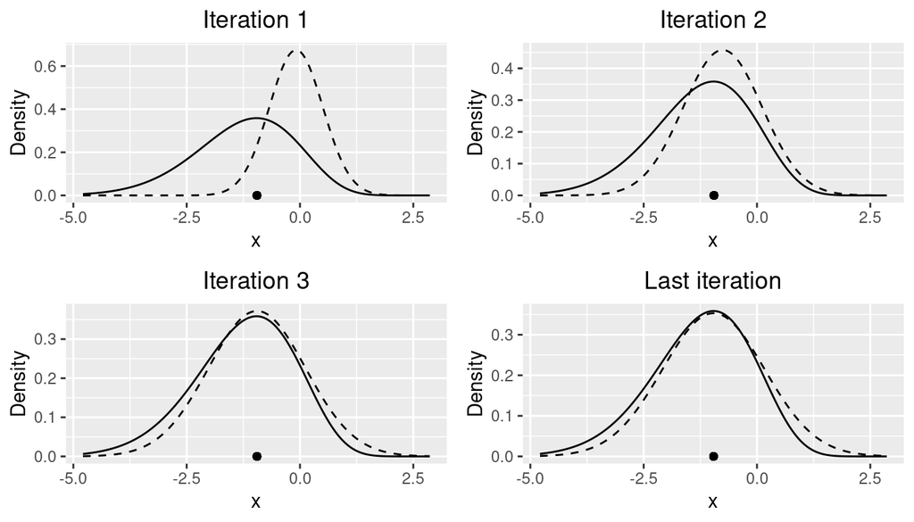

## Wrapping everything in a function for optimisation

The function `la_nngp()` compute the precision matrix of NNGP and the Laplace approximation returning the log likelihood of the Poisson-NNGP model given a vector of parameters.

```r
# Estimating parameters
la_nngp <- function(y, Z, coords, p0, x0, grad, hess, m) {
  print(c(exp(p0[1:2]), p0[3:4]))
  betas <- p0[3:4]

  # Vecchia Approx
  nngp_decomp <- nngp_chol(coords, m, exp(p0))

  Cinv <- crossprod(nngp_decomp$L)
  C <- chol2inv(chol(Cinv))

  # Laplace Approximation
  gauss <- la(x0, y, Z, betas, Cinv, grad, hess)
  x_hat <- gauss$mu
  Cx <- gauss$sigma

  # Log-likelihood
  denom <- -(length(y) / 2) * log(2 * pi) - 0.5 * determinant(Cx)$modulus[1]
  ll <- posterior(y, x_hat, Z, C, betas) - denom
  return(ll)
}
```

# Simulation study

Consider a data

$$\begin{align*}
\boldsymbol{x} & \sim \mathcal{N} \left( \boldsymbol{0},
\boldsymbol{C}(\boldsymbol{\psi}) \right) \\
y_i \mid \boldsymbol{x} & \overset{iid}\sim Poisson(\eta_i), \quad
\eta_i = \exp \left\{ \beta_0 + \beta_1 z_i + x_i \right\} \\
z_i & \overset{iid}\sim \mathcal{N}(2, 1) \\
\boldsymbol{\theta} & = (\boldsymbol{\psi}, \boldsymbol{\beta}) =
(2.6, 0.4, -0.5, 1.5),
\end{align*}$$

where the covariance matrix $C(\boldsymbol{\psi})$ is the Squared Exponential (SE) kernel in terms of signal variance and length-scale parameterization

$$\begin{equation*}
\mathrm{C}(s_i, s_j) = \sigma^2 \exp \left\{ -\frac{(s_i - s_j)^2}{2
l^2} \right\}.
\end{equation*}$$

```r
n <- 500
set.seed(163)
coords <- cbind(runif(n, max = 3), runif(n, max = 3))

ord <- order(coords[,1])
coords <- coords[ord,]

sigma <- 2.6
l <- .4
betas <- c(-.5, 1.5)

d <- dist(coords) |>
  as.matrix()
C <- sigma^2 * exp(-d / (2 * l^2))
x <- rmvnorm(1, sigma = C, method = "chol", checkSymmetry = F) |>
  c()
Z <- model.matrix(~rnorm(n, 2))
eta <- exp(x + Z %*% betas)
y <- rpois(n, eta)
```

We have to define the log posterior of the parameters, the gradient and hessian function of the data likelihood.

```r
# pi(theta | x, y) \propto pi(y | x, theta) * pi(x | theta)
posterior <- function(y, x, Z, sigma_x, betas, log = T) {
  eta <- exp(x + Z %*% betas)
  ll <- sum(dpois(y, eta, log = T)) +
    dmvnorm(x, sigma = sigma_x, log = T, checkSymmetry = F)
  if (!log) {
    ll <- exp(ll)
  }
  return(ll)
}

grad <- function(x, y, Z, betas) {
  (y - exp(x + Z %*% betas)) |>
    as.vector()
}

hess <- function(x, Z, betas) {
  -exp(x + Z %*% betas) |>
    as.vector()
}
```

The code bellow estimate the parameters maximizing the log-likelihood, considering the NNGP with neighbour size $m = 10$.

```r
p0 <- c(log(5), log(5), 0, 1)
x0 <- log(y + .5)
m <- 10

fitted_parms <- optim(
  p0, la_nngp, y = y, Z = Z, coords = coords, x0 = x0, grad = grad, hess = hess, m = m,
  method = "Nelder-Mead", hessian = T, control = list(fnscale = -1))
```

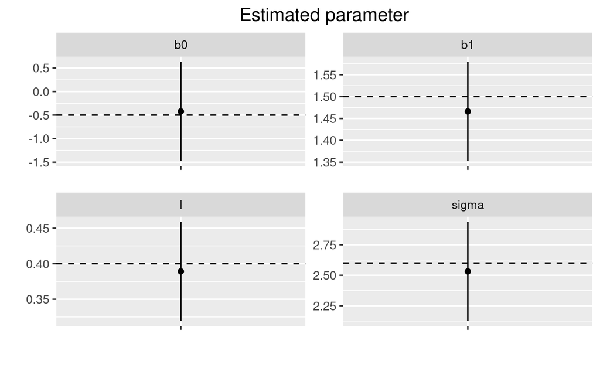

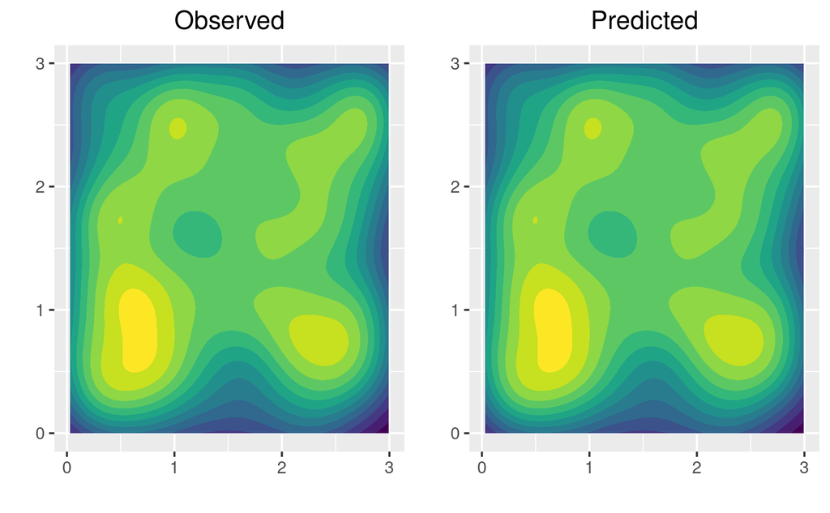

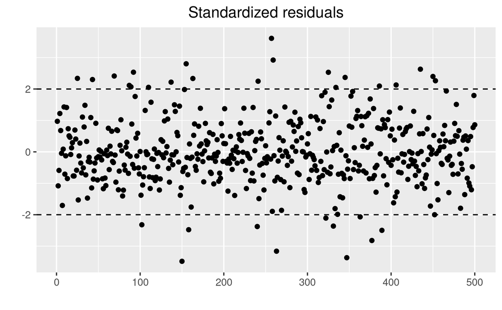

# References

Zilber, Daniel, and Matthias Katzfuss. 2021. “Vecchia–Laplace Approximations of Generalized Gaussian Processes for Big Non-Gaussian Spatial Data.” *Computational Statistics & Data Analysis* 153: 107081.